# Actualización datos ley 23737

SNEEP cargo los datos de 2019. Hay que actualizar la misma info q teniamos hasta 2018. - https://github.com/datos-justicia-argentina/Sistema-Nacional-de-Estadisticas-sobre-Ejecucion-de-la-Pena-SNEEP/blob/master/Sistema-Nacional-de-Estadisticas-sobre-Ejecucion-de-la-Pena-SNEEP-metadata.md - http://datos.jus.gob.ar/dataset/sneep

```r
library(dplyr)
library(ggplot2)
library(readr)
library(tidyr)

# sneep <- read_csv("C:/Users/Usuario/Desktop/Lucas/1- pe/7- ley 23737/data/sneep-unificado-2002-2019.csv")
sneep <- read_csv("/Users/lucaspecina/Desktop/Data/Planificacion Estrategica/presos 23737/data/sneep-unificado-2002-2019.csv")
```

[output not shown]

Todos los delitos provinciales y de PBA (les saco los federales y dejo solo PBA)

```r
# esto deja solo las provinciales
provinciales <- sneep %>% filter(anio_censo>=2005 & reparticion_descripcion=='Provincial')

# delitos totales de la PBA
pba <- provinciales %>% filter(provincia_descripcion=='Buenos Aires')
```

Delitos ley 23737 de PBA

```r
# ley 23737
ley23737_pba <- pba %>%

  filter((delito1_descripcion=='Infracción ley n° 23.737 (estupefacientes)' | delito2_descripcion=='Infracción ley n° 23.737 (estupefacientes)' |
         delito3_descripcion=='Infracción ley n° 23.737 (estupefacientes)' | delito4_descripcion=='Infracción ley n° 23.737 (estupefacientes)' |
         delito5_descripcion=='Infracción ley n° 23.737 (estupefacientes)'))
```

## Analisis basicos para la PBA

Cantidad de presos totales por año

```r
# cantidad de presos totales
presos_total_por_anio <- pba %>% group_by(anio_censo) %>% summarise(presos_totales= n())
# cantidad de presos por ley23737
presos_ley23737_por_anio <- ley23737_pba %>% group_by(anio_censo) %>% summarise(presos_ley23737= n())
# joineo
presos_porcen23737_por_anio <- presos_total_por_anio %>% inner_join(presos_ley23737_por_anio, by='anio_censo')
# calculo porcentaje
presos_porcen23737_por_anio <- presos_porcen23737_por_anio %>% mutate(porcen_ley23737 = (presos_ley23737/presos_totales*100))

print(presos_porcen23737_por_anio)
```

[output not shown]

Cantidad de presos por 23737 por año

```r
data_plot <- presos_porcen23737_por_anio %>% pivot_longer(c(presos_totales,presos_ley23737), names_to='tipo', values_to='cantidad')

ggplot(data_plot, aes(x=anio_censo,y=cantidad,color=tipo)) + geom_line() + geom_point() +
    labs(title="Provincia de Buenos Aires",x="Año de censo", y = "Cantidad de presos")
```

[output not shown]

## Analisis para todas las provincias

Delitos ley 23737 de provincias

```r
# ley 23737
ley23737_provs <- provinciales %>%

  filter((delito1_descripcion=='Infracción ley n° 23.737 (estupefacientes)' | delito2_descripcion=='Infracción ley n° 23.737 (estupefacientes)' |
         delito3_descripcion=='Infracción ley n° 23.737 (estupefacientes)' | delito4_descripcion=='Infracción ley n° 23.737 (estupefacientes)' |
         delito5_descripcion=='Infracción ley n° 23.737 (estupefacientes)')) %>%

  filter(provincia_id==jurisdiccion_id)
```

Cantidad de presos totales por año

```r
# cantidad de presos totales
presos_total_por_anio_prov <- provinciales %>% group_by(anio_censo,provincia_descripcion) %>% summarise(presos_totales= n())
# cantidad de presos droga por año y provincia
presos_ley23737_por_anio_prov <- ley23737_provs %>% group_by(anio_censo,provincia_descripcion) %>% summarise(presos_ley23737= n())
# joineo
presos_porcen23737_por_anio_prov <- presos_total_por_anio_prov %>% inner_join(presos_ley23737_por_anio_prov, by=c('anio_censo','provincia_descripcion'))
# calculo porcentaje
presos_porcen23737_por_anio_prov <- presos_porcen23737_por_anio_prov %>% mutate(porcen_ley23737 = (presos_ley23737/presos_totales*100))

presos_porcen23737_por_anio_prov <- presos_porcen23737_por_anio_prov %>%
          filter(
              (provincia_descripcion=='Buenos Aires') |
                (provincia_descripcion=='Chaco' & anio_censo>=2015) |
                (provincia_descripcion=='Córdoba' & anio_censo>=2012) |
                (provincia_descripcion=='Formosa' & anio_censo>=2015) |
                (provincia_descripcion=='Salta' & anio_censo>=2014) |
                (provincia_descripcion=='Entre Rios' & anio_censo>=2018) |
                (provincia_descripcion=='Santiago del Estero' & anio_censo>=2018)
            )

print(presos_porcen23737_por_anio_prov)
```

[output not shown]

```r
ggplot(presos_porcen23737_por_anio_prov, aes(x=anio_censo,y=porcen_ley23737,color=provincia_descripcion)) + geom_line() + geom_point() +
    labs(title="Provincias elegidas",x="Año de censo", y = "Porcentaje de presos por 23737")
```

[output not shown]

## Por provincia y por genero

```r
# ley 23737
ley23737_provs <- provinciales %>%

  filter((delito1_descripcion=='Infracción ley n° 23.737 (estupefacientes)' | delito2_descripcion=='Infracción ley n° 23.737 (estupefacientes)' |
         delito3_descripcion=='Infracción ley n° 23.737 (estupefacientes)' | delito4_descripcion=='Infracción ley n° 23.737 (estupefacientes)' |
         delito5_descripcion=='Infracción ley n° 23.737 (estupefacientes)')) %>%

  filter(provincia_id==jurisdiccion_id)
```

Cantidad de presos totales por año

```r
# cantidad de presos totales
presos_total_por_anio_prov <- provinciales %>% group_by(anio_censo,provincia_descripcion) %>% summarise(presos_totales= n())
# cantidad de presos droga por año y provincia
presos_ley23737_por_anio_prov <- ley23737_provs %>% group_by(anio_censo,provincia_descripcion) %>% summarise(presos_ley23737= n())
# joineo
presos_porcen23737_por_anio_prov <- presos_total_por_anio_prov %>% inner_join(presos_ley23737_por_anio_prov, by=c('anio_censo','provincia_descripcion'))

presos_porcen23737_por_anio_prov <- presos_porcen23737_por_anio_prov %>%
          filter(
              (provincia_descripcion=='Buenos Aires') |
                (provincia_descripcion=='Chaco' & anio_censo>=2015) |
                (provincia_descripcion=='Córdoba' & anio_censo>=2012) |
                (provincia_descripcion=='Formosa' & anio_censo>=2015) |
                (provincia_descripcion=='Salta' & anio_censo>=2014) |
                (provincia_descripcion=='Entre Rios' & anio_censo>=2018) |
                (provincia_descripcion=='Santiago del Estero' & anio_censo>=2018)
            )



# POR GENERO
mujeres_total <- provinciales %>% filter(genero_descripcion=='Femenino') %>% group_by(anio_censo,provincia_descripcion) %>%
  summarise(mujeres_total= n())
presos_porcen23737_por_anio_prov <- presos_porcen23737_por_anio_prov %>% left_join(mujeres_total,by=c('anio_censo','provincia_descripcion'))

mujeres_droga <- ley23737_provs %>% filter(genero_descripcion=='Femenino') %>% group_by(anio_censo,provincia_descripcion) %>%
  summarise(mujeres_droga= n())
presos_porcen23737_por_anio_prov <- presos_porcen23737_por_anio_prov %>% left_join(mujeres_droga,by=c('anio_censo','provincia_descripcion'))

varones_total <- provinciales %>% filter(genero_descripcion=='Masculino') %>% group_by(anio_censo,provincia_descripcion) %>%
  summarise(varones_total= n())
presos_porcen23737_por_anio_prov <- presos_porcen23737_por_anio_prov %>% left_join(varones_total,by=c('anio_censo','provincia_descripcion'))

varones_droga <- ley23737_provs %>% filter(genero_descripcion=='Masculino') %>% group_by(anio_censo,provincia_descripcion) %>%
  summarise(varones_droga= n())
presos_porcen23737_por_anio_prov <- presos_porcen23737_por_anio_prov %>% left_join(varones_droga,by=c('anio_censo','provincia_descripcion'))

transexual_total <- provinciales %>% filter(genero_descripcion=='Transexual') %>% group_by(anio_censo,provincia_descripcion) %>%
  summarise(transexual_total= n())
presos_porcen23737_por_anio_prov <- presos_porcen23737_por_anio_prov %>% left_join(transexual_total,by=c('anio_censo','provincia_descripcion'))

transexual_droga <- ley23737_provs %>% filter(genero_descripcion=='Transexual') %>% group_by(anio_censo,provincia_descripcion) %>%
  summarise(transexual_droga= n())
presos_porcen23737_por_anio_prov <- presos_porcen23737_por_anio_prov %>% left_join(transexual_droga,by=c('anio_censo','provincia_descripcion'))

# reemplazo los NA con 0
presos_porcen23737_por_anio_prov <- presos_porcen23737_por_anio_prov %>% replace(is.na(.), 0)

# calculo porcentajes
presos_porcen23737_por_anio_prov <- presos_porcen23737_por_anio_prov %>% mutate(porcen_ley23737 = (presos_ley23737/presos_totales*100))
# de total de GENERO, cuantas son por droga
presos_porcen23737_por_anio_prov <- presos_porcen23737_por_anio_prov %>% mutate(
      mujeres_porcen_droga = mujeres_droga/mujeres_total*100,
      varones_porcen_droga = varones_droga/varones_total*100,
      transexuales_porcen_droga = transexual_droga/transexual_total*100)
# del total de delitos, que porcentaje por genero
presos_porcen23737_por_anio_prov <- presos_porcen23737_por_anio_prov %>% mutate(
      total_porcen_mujeres = mujeres_total/(mujeres_total+varones_total+transexual_total)*100,
      total_porcen_varones = varones_total/(mujeres_total+varones_total+transexual_total)*100,
      total_porcen_transexuales = transexual_total/(mujeres_total+varones_total+transexual_total)*100)
# de delitos droga, que porcentaje por genero
presos_porcen23737_por_anio_prov <- presos_porcen23737_por_anio_prov %>% mutate(
      droga_porcen_mujeres = mujeres_droga/(mujeres_droga+varones_droga+transexual_droga)*100,
      droga_porcen_varones = varones_droga/(mujeres_droga+varones_droga+transexual_droga)*100,
      droga_porcen_transexuales = transexual_droga/(mujeres_droga+varones_droga+transexual_droga)*100)

presos_porcen23737_por_anio_prov
```

[output not shown]

## Procesados y condenados por droga y no droga

Primero saco los otros que no sean condenados y procesados y a eso le aplico lo de provinciales

```r
provinciales <- sneep %>% filter((situacion_legal_descripcion=='Procesado') | (situacion_legal_descripcion=='Condenado')) %>%
  filter(anio_censo>=2005 & reparticion_descripcion=='Provincial')
```

Dejo solo los que no son de drogas

```r
# delitos por NO ley 23737
NOdroga_provs <- provinciales %>%
  filter(
    ((delito1_descripcion!='Infracción ley n° 23.737 (estupefacientes)') | (is.na(delito1_descripcion))) &
    ((delito2_descripcion!='Infracción ley n° 23.737 (estupefacientes)') | (is.na(delito2_descripcion))) &
    ((delito3_descripcion!='Infracción ley n° 23.737 (estupefacientes)') | (is.na(delito3_descripcion))) &
    ((delito4_descripcion!='Infracción ley n° 23.737 (estupefacientes)') | (is.na(delito4_descripcion))) &
    ((delito5_descripcion!='Infracción ley n° 23.737 (estupefacientes)') | (is.na(delito5_descripcion)))) %>%
  filter(provincia_id==jurisdiccion_id) %>%
  filter(
    (provincia_descripcion=='Buenos Aires') |
      (provincia_descripcion=='Chaco' & anio_censo>=2015) |
      (provincia_descripcion=='Córdoba' & anio_censo>=2012) |
      (provincia_descripcion=='Formosa' & anio_censo>=2015) |
      (provincia_descripcion=='Salta' & anio_censo>=2014) |
      (provincia_descripcion=='Entre Rios' & anio_censo>=2018) |
      (provincia_descripcion=='Santiago del Estero' & anio_censo>=2018)
  )
```

Saco los numeros y porcentajes de procesados para los no droga

```r
procesados_NOdroga <- NOdroga_provs %>% filter(situacion_legal_descripcion=='Procesado') %>%
  group_by(anio_censo,provincia_descripcion) %>% summarise(procesados_NOdroga= n())
condenados_NOdroga <- NOdroga_provs %>% filter(situacion_legal_descripcion=='Condenado') %>%
  group_by(anio_censo,provincia_descripcion) %>% summarise(condenados_NOdroga= n())
# join
procesados_porcen_NOdroga <- procesados_NOdroga %>% inner_join(condenados_NOdroga, by=c('anio_censo','provincia_descripcion'))
# calculo porcentajes
procesados_porcen_NOdroga <- procesados_porcen_NOdroga %>% mutate(procesados_porcen_NOdroga = procesados_NOdroga/(procesados_NOdroga+condenados_NOdroga))
```

Dejo solo los que son de drogas

```r
# delitos por NO ley 23737
droga_provs <- provinciales %>%
    filter((delito1_descripcion=='Infracción ley n° 23.737 (estupefacientes)' |
            delito2_descripcion=='Infracción ley n° 23.737 (estupefacientes)' |
            delito3_descripcion=='Infracción ley n° 23.737 (estupefacientes)' |
            delito4_descripcion=='Infracción ley n° 23.737 (estupefacientes)' |
            delito5_descripcion=='Infracción ley n° 23.737 (estupefacientes)')) %>%
  filter(provincia_id==jurisdiccion_id) %>%
  filter(
    (provincia_descripcion=='Buenos Aires') |
      (provincia_descripcion=='Chaco' & anio_censo>=2015) |
      (provincia_descripcion=='Córdoba' & anio_censo>=2012) |
      (provincia_descripcion=='Formosa' & anio_censo>=2015) |
      (provincia_descripcion=='Salta' & anio_censo>=2014) |
      (provincia_descripcion=='Entre Rios' & anio_censo>=2018) |
      (provincia_descripcion=='Santiago del Estero' & anio_censo>=2018)
  )
```

Saco los numeros y porcentajes de procesados para los de droga

```r
procesados_droga <- droga_provs %>% filter(situacion_legal_descripcion=='Procesado') %>%
  group_by(anio_censo,provincia_descripcion) %>% summarise(procesados_droga= n())
condenados_droga <- droga_provs %>% filter(situacion_legal_descripcion=='Condenado') %>%
  group_by(anio_censo,provincia_descripcion) %>% summarise(condenados_droga= n())
# join
procesados_porcen_droga <- procesados_droga %>% inner_join(condenados_droga, by=c('anio_censo','provincia_descripcion'))
# calculo porcentajes
procesados_porcen_droga <- procesados_porcen_droga %>% mutate(procesados_porcen_droga = procesados_droga/(procesados_droga+condenados_droga))
```

Joineo los resultados de drogas y no drogas

```r
procesados_porcen_todos <- procesados_porcen_droga %>% inner_join(procesados_porcen_NOdroga, by=c('anio_censo','provincia_descripcion'))

# hago la resta
procesados_porcen_todos <- procesados_porcen_todos %>% mutate(diferencia_procesados = procesados_porcen_droga - procesados_porcen_NOdroga)
```

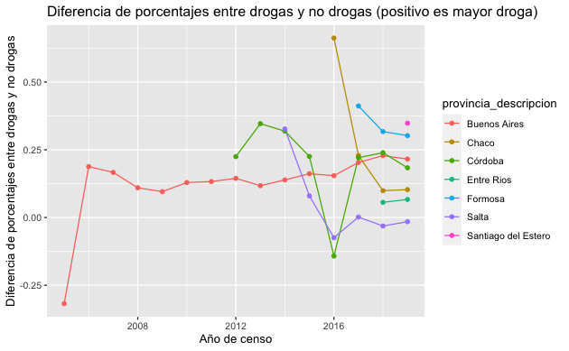

```r
ggplot(procesados_porcen_todos, aes(x=anio_censo,y=diferencia_procesados,color=provincia_descripcion)) + geom_line() + geom_point() +
    labs(title="Diferencia de porcentajes entre drogas y no drogas (positivo es mayor droga)",x="Año de censo", y = "Diferencia de porcentajes entre drogas y no drogas")
```